# Activity 9: PCA

Jae Salazar

2026-06-18

# A. Principal Component Analysis

## Step 2: Read in the frogs’ data as a dataframe.

```r
frogs <- read.csv("D:/Files/DLSU Files/Year 3 Term 3/LBBBI27/Activity 9/Meneses_et.al_2026_Platymantis.csv")
```

## Step 3: Subset your data to retain only the “Species” column and morphological features (e.g., SVL, HL, SNL, etc.) from columns 10 through the last one (i.e., 10:X).

```r
frogsubset <- frogs[, c(10:34)]
frogsubset <- cbind(Species = frogs$Species, frogsubset)
```

## Step 4: Check the class and structure of the subset data. How many morphological features are present in the dataset?

```r
str(frogsubset)
```

```
## 'data.frame':    139 obs. of  26 variables:
##  $ Species         : chr  "P_guiting" "P_guiting" "P_guiting" "P_guiting" ...
##  $ S.V.L.          : num  13.5 14.5 15.1 15.6 14.2 13.1 14.8 15.3 14.6 16.5 ...
##  $ H.L.            : num  6.2 6.4 6.6 6.7 6.4 6 6.4 6.3 5.7 6 ...
##  $ SNL             : num  2.1 2.4 2.8 2.8 2.4 2.5 2.5 2.5 2.4 2.4 ...
##  $ ED              : num  1.6 1.5 1.7 1.9 1.5 1.6 2.1 1.6 1.7 2 ...
##  $ TD              : num  1.1 1.1 1.2 1.1 1.1 1.1 1 1.2 1.3 1.1 ...
##  $ E.N             : num  1.2 1.2 1.6 1.5 1.2 1.5 1.3 1.7 1.5 1.2 ...
##  $ IND             : num  1.4 1.6 1.7 1.9 2.1 1.8 2.1 1.7 1.7 1.8 ...
##  $ IOD             : num  1.7 1.7 1.5 1.7 1.7 1.7 1.9 2.2 2.1 1.9 ...
##  $ H.W.            : num  5.7 6.4 5.7 6 5.9 5.9 6.2 6.6 6 6.8 ...
##  $ forearm         : num  3.1 4.5 4 4 4 3.8 4 4.2 4 4 ...
##  $ femur           : num  6.6 7.6 7.6 8.9 6.8 7.5 6.9 9.1 7.6 8 ...
##  $ tibia           : num  6.9 7.5 7.8 8.9 6.8 7.2 6.7 8 6.7 7.8 ...
##  $ tarsus          : num  4.1 4.6 5 5.4 4.6 4.3 4.2 5.3 4.6 4.6 ...
##  $ foot            : num  6 7.5 7.4 8.1 5.8 6.4 6 7.6 6.8 7.5 ...
##  $ hand            : num  3.2 3.2 3.7 4 3.4 3.1 3.4 3.5 3.1 3.3 ...
##  $ Toe4L           : num  4.2 4.1 4 5.2 4.1 4.1 4.6 4.4 4.4 4.3 ...
##  $ Fin1L           : num  1.3 1.9 1.7 2.2 1.7 1.6 1.8 1.5 2 1.4 ...
##  $ Fin3L           : num  1.9 2.3 2.2 2.3 2.3 2 1.9 1.7 1.8 1.9 ...
##  $ X3rd.fin.DW     : num  0.2 0.4 0.3 0.2 0.4 0.3 0.2 0.3 0.5 0.4 ...
##  $ X3rd.FinPF.width: num  0.2 0.3 0.3 0.2 0.3 0.2 0.2 0.2 0.4 0.4 ...
##  $ Toe.4.DW        : num  0.5 0.4 0.5 0.3 0.5 0.4 0.4 0.6 0.5 0.4 ...
##  $ Toe.4.PF.width  : num  0.3 0.3 0.3 0.3 0.3 0.3 0.3 0.4 0.3 0.3 ...
##  $ PP.FinD3W       : num  1 0.8 1 1 0.8 0.7 1 0.7 0.8 1 ...
##  $ PP.Toe4DW       : num  0.6 0.8 0.6 1 0.6 0.8 0.8 0.7 0.6 0.8 ...
##  $ Toe4DW.Fin3DW   : num  2.5 1 1.7 1.5 1.3 1.3 2 2 1 1 ...
```

There are 25 morphological features present in the dataset.

## Step 5: Ensure the dataframe has no NAs.

```r
frogclean <- frogsubset[complete.cases(frogsubset), ]
```

## Step 6: Scale the data using only the numeric columns, then compute the pairwise correlations. Do not further subset the data.

```r
frogscale <- frogclean[, 2:26]
cor_mat <- cor(frogscale)
round(cor_mat, 2)
```

```
##                  S.V.L.  H.L.   SNL    ED    TD   E.N   IND   IOD  H.W. forearm
## S.V.L.             1.00  0.65  0.41  0.52  0.50  0.37  0.45  0.56  0.76    0.45
## H.L.               0.65  1.00  0.23  0.54  0.57  0.36  0.35  0.44  0.52    0.27
## SNL                0.41  0.23  1.00  0.10  0.17  0.51  0.44  0.33  0.36    0.36
## ED                 0.52  0.54  0.10  1.00  0.70  0.29  0.21  0.42  0.38    0.21
## TD                 0.50  0.57  0.17  0.70  1.00  0.40  0.25  0.49  0.41    0.25
## E.N                0.37  0.36  0.51  0.29  0.40  1.00  0.31  0.43  0.24    0.23
## IND                0.45  0.35  0.44  0.21  0.25  0.31  1.00  0.32  0.45    0.25
## IOD                0.56  0.44  0.33  0.42  0.49  0.43  0.32  1.00  0.48    0.46
## H.W.               0.76  0.52  0.36  0.38  0.41  0.24  0.45  0.48  1.00    0.54
## forearm            0.45  0.27  0.36  0.21  0.25  0.23  0.25  0.46  0.54    1.00
## femur              0.27  0.00  0.09 -0.08 -0.20 -0.13  0.09  0.15  0.33    0.45
## tibia              0.18 -0.05  0.00 -0.22 -0.35 -0.27  0.01 -0.03  0.17    0.34
## tarsus             0.39  0.08  0.18 -0.08 -0.16 -0.06  0.13  0.18  0.34    0.48
## foot               0.40  0.15  0.08  0.04 -0.11 -0.12  0.06  0.15  0.38    0.45
## hand               0.53  0.34  0.17  0.29  0.22  0.10  0.24  0.20  0.48    0.27
## Toe4L              0.51  0.40  0.13  0.31  0.23  0.12  0.18  0.36  0.43    0.38
## Fin1L              0.57  0.37  0.14  0.38  0.28  0.11  0.21  0.29  0.45    0.37
## Fin3L              0.44  0.38  0.15  0.42  0.34  0.12  0.19  0.29  0.39    0.27
## X3rd.fin.DW        0.46  0.32  0.15  0.27  0.22  0.10  0.35  0.20  0.41    0.27
## X3rd.FinPF.width   0.53  0.30  0.17  0.42  0.43  0.13  0.31  0.34  0.50    0.30
## Toe.4.DW           0.38  0.28  0.03  0.27  0.16 -0.05  0.23  0.31  0.35    0.27
## Toe.4.PF.width     0.36  0.32  0.09  0.38  0.28  0.08  0.24  0.40  0.34    0.20
## PP.FinD3W          0.02 -0.06 -0.06  0.13  0.19  0.02 -0.08  0.12  0.06    0.02
## PP.Toe4DW         -0.11 -0.02  0.06  0.05  0.07  0.13 -0.05  0.05 -0.07   -0.12
## Toe4DW.Fin3DW     -0.13 -0.11 -0.15 -0.04 -0.11 -0.16 -0.16  0.07 -0.11   -0.04
##                  femur tibia tarsus  foot  hand Toe4L Fin1L Fin3L X3rd.fin.DW
## S.V.L.            0.27  0.18   0.39  0.40  0.53  0.51  0.57  0.44        0.46
## H.L.              0.00 -0.05   0.08  0.15  0.34  0.40  0.37  0.38        0.32
## SNL               0.09  0.00   0.18  0.08  0.17  0.13  0.14  0.15        0.15
## ED               -0.08 -0.22  -0.08  0.04  0.29  0.31  0.38  0.42        0.27
## TD               -0.20 -0.35  -0.16 -0.11  0.22  0.23  0.28  0.34        0.22
## E.N              -0.13 -0.27  -0.06 -0.12  0.10  0.12  0.11  0.12        0.10
## IND               0.09  0.01   0.13  0.06  0.24  0.18  0.21  0.19        0.35
## IOD               0.15 -0.03   0.18  0.15  0.20  0.36  0.29  0.29        0.20
## H.W.              0.33  0.17   0.34  0.38  0.48  0.43  0.45  0.39        0.41
## forearm           0.45  0.34   0.48  0.45  0.27  0.38  0.37  0.27        0.27
## femur             1.00  0.87   0.80  0.78  0.21  0.46  0.29  0.04        0.19
## tibia             0.87  1.00   0.85  0.80  0.21  0.50  0.24 -0.01        0.09
## tarsus            0.80  0.85   1.00  0.78  0.29  0.56  0.39  0.13        0.20
```

[output cut: 49 more lines]

```
## femur                     0.14
## tibia                     0.21
## tarsus                    0.14
## foot                      0.09
## hand                     -0.07
## Toe4L                     0.16
## Fin1L                    -0.16
## Fin3L                    -0.21
## X3rd.fin.DW              -0.62
## X3rd.FinPF.width         -0.30
## Toe.4.DW                  0.41
## Toe.4.PF.width            0.27
## PP.FinD3W                 0.40
## PP.Toe4DW                -0.23
## Toe4DW.Fin3DW             1.00
```

```r
frogscale2 <- as.matrix(frogscale)
```

## Step 7: Use the correlation matrix to calculate the eigenvectors and the proportion of variance (expressed in percentage). How many principal components were produced? What is the proportion of variance explained by components 1–4?

```r
eig <- eigen(cor_mat)
prop_var <- eig$values / sum(eig$values)
prop_var[1:4]
```

```
## [1] 0.29858017 0.16505790 0.08614588 0.06794091
```

```r
sum(prop_var[1:4])
```

```
## [1] 0.6177249
```

```r
eig_vec <- eig$vectors
scores <- frogscale2 %*% eig_vec
```

25 principal components were produced. The proportion of variance explained by the 1st to 4th principal components are 29.86, 16.51, 8.61, and 6.79 percent respectively; collectively, those four account for 61.77 percent of the variance.

## Step 8: Now, create a 1x2 plot showing the screeplot and the PCA biplot. You can use either base R or ggplot2. You can be creative here by coloring the point shapes per species and adding a legend. Consider the high data-ink ratio you learned from the lecture.

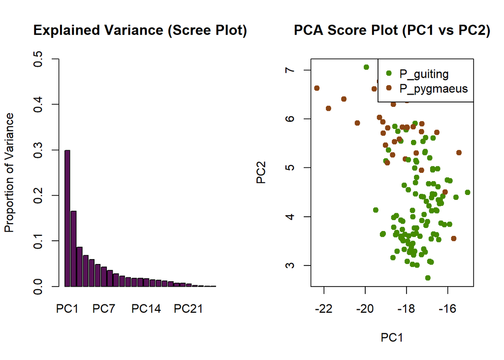

```r
layout(matrix(c(1,2), 1, 2), widths = c(10,10))

barplot(prop_var,
  names.arg = paste0("PC", 1:25),
  ylim = c(0, 0.5),
  col = "#591258",
  main = "Explained Variance (Scree Plot)",
  ylab = "Proportion of Variance")

plot(scores[,1], scores[,2],
  xlab = "PC1",
  ylab = "PC2",
  main = "PCA Score Plot (PC1 vs PC2)",
  pch = 19,
  col = c("chartreuse4","chocolate4")[as.numeric(factor(frogsubset$Species))])
legend("topright",
  legend = levels(factor(frogsubset$Species)),
  col = c("chartreuse4", "chocolate4"),
  pch = 19)
```

# Broken-stick vs PCAtest

## Step 1: Examine the variance explained by principal components using the Broken-stick method and the PCAtest package. What is the difference between these two methods for assessing the importance of principal components?

The broken stick method provides principal component importance by providing numeric and visual comparisons of observed and broken-stick variances; The PCAtest code provides importance by showing significance values and their variation accounts, and significant individual variable loadings on the principal components.

## Step 2: Create a barplot showing the results of Broken-stick analysis and perform a significance test for principal components using PCAtest, following the instructions at https://arleyc.github.io/PCAtest/.

```r
broken_stick <- function(p){
  sapply(1:p, function(k){
    sum(1 / (k:p) / p)
  })
}

bs <- broken_stick(ncol(frogscale2))
bs
```

```
##  [1] 0.152638327 0.112638327 0.092638327 0.079304994 0.069304994 0.061304994
##  [7] 0.054638327 0.048924041 0.043924041 0.039479597 0.035479597 0.031843233
## [13] 0.028509900 0.025432977 0.022575834 0.019909167 0.017409167 0.015056226
## [19] 0.012834004 0.010728741 0.008728741 0.006823979 0.005005797 0.003266667
## [25] 0.001600000
```

```r
comparison <- data.frame(
  PC = paste0("PC", 1:25),
  Observed = prop_var,
  BrokenStick = bs
)
comparison
```

```
##      PC     Observed BrokenStick
## 1   PC1 0.2985801655 0.152638327
## 2   PC2 0.1650578992 0.112638327
## 3   PC3 0.0861458783 0.092638327
## 4   PC4 0.0679409124 0.079304994
## 5   PC5 0.0587827127 0.069304994
## 6   PC6 0.0483996540 0.061304994
## 7   PC7 0.0423509340 0.054638327
## 8   PC8 0.0348849038 0.048924041
## 9   PC9 0.0278582508 0.043924041
## 10 PC10 0.0229774830 0.039479597
## 11 PC11 0.0198364720 0.035479597
## 12 PC12 0.0181221550 0.031843233
## 13 PC13 0.0178398191 0.028509900
## 14 PC14 0.0166433080 0.025432977
## 15 PC15 0.0143991010 0.022575834
## 16 PC16 0.0135746421 0.019909167
## 17 PC17 0.0121964047 0.017409167
## 18 PC18 0.0101001492 0.015056226
## 19 PC19 0.0073637134 0.012834004
## 20 PC20 0.0069074715 0.010728741
## 21 PC21 0.0052986522 0.008728741
## 22 PC22 0.0024132440 0.006823979
## 23 PC23 0.0012206068 0.005005797
## 24 PC24 0.0007559683 0.003266667
## 25 PC25 0.0003494991 0.001600000
```

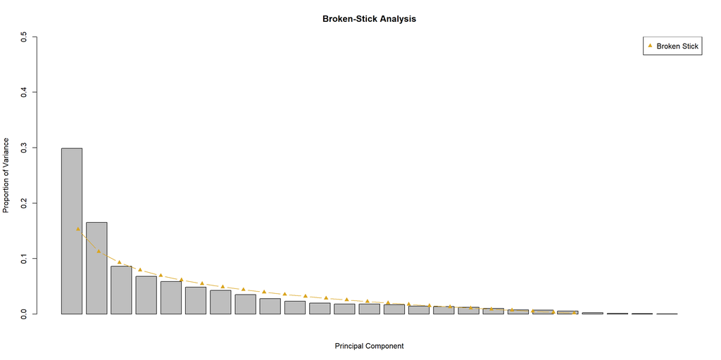

```r
barplot(prop_var,
  type = "b",
  pch = 19,
  ylim = c(0, 0.5),
  xlab = "Principal Component",
  ylab = "Proportion of Variance",
  main = "Broken-Stick Analysis")
lines(bs,
  type = "b",
  pch = 17,
  col = "goldenrod")
legend("topright",
  legend = c("Broken Stick"),
  pch = c(17),
  col = c("goldenrod"))
```

```r
library(PCAtest)
pcatest <- PCAtest(frogscale, 100, 100, 0.05, varcorr = FALSE, counter = FALSE, plot = TRUE)
```

[output not shown]

```
##
## Sampling bootstrap replicates... Please wait
##
## Calculating confidence intervals of empirical statistics... Please wait
##
## Sampling random permutations... Please wait
##
## Comparing empirical statistics with their null distributions... Please wait
##
## ========================================================
## Test of PCA significance: 25 variables, 139 observations
## 100 bootstrap replicates, 100 random permutations
## ========================================================
##
## Empirical Psi = 62.9009, Max null Psi = 5.4047, Min null Psi = 3.4655, p-value = 0
## Empirical Phi = 0.3238, Max null Phi = 0.0949, Min null Phi = 0.0760, p-value = 0
##
## Empirical eigenvalue #1 = 7.4645, Max null eigenvalue = 2.14423, p-value = 0
## Empirical eigenvalue #2 = 4.12645, Max null eigenvalue = 1.89195, p-value = 0
## Empirical eigenvalue #3 = 2.15365, Max null eigenvalue = 1.77358, p-value = 0
## Empirical eigenvalue #4 = 1.69852, Max null eigenvalue = 1.65208, p-value = 0
## Empirical eigenvalue #5 = 1.46957, Max null eigenvalue = 1.56005, p-value = 0.26
## Empirical eigenvalue #6 = 1.20999, Max null eigenvalue = 1.45163, p-value = 1
## Empirical eigenvalue #7 = 1.05877, Max null eigenvalue = 1.38312, p-value = 1
## Empirical eigenvalue #8 = 0.87212, Max null eigenvalue = 1.3058, p-value = 1
## Empirical eigenvalue #9 = 0.69646, Max null eigenvalue = 1.24258, p-value = 1
## Empirical eigenvalue #10 = 0.57444, Max null eigenvalue = 1.18479, p-value = 1
## Empirical eigenvalue #11 = 0.49591, Max null eigenvalue = 1.11491, p-value = 1
## Empirical eigenvalue #12 = 0.45305, Max null eigenvalue = 1.064, p-value = 1
## Empirical eigenvalue #13 = 0.446, Max null eigenvalue = 1.01862, p-value = 1
## Empirical eigenvalue #14 = 0.41608, Max null eigenvalue = 0.96407, p-value = 1
## Empirical eigenvalue #15 = 0.35998, Max null eigenvalue = 0.91224, p-value = 1
## Empirical eigenvalue #16 = 0.33937, Max null eigenvalue = 0.86368, p-value = 1
## Empirical eigenvalue #17 = 0.30491, Max null eigenvalue = 0.82126, p-value = 1
## Empirical eigenvalue #18 = 0.2525, Max null eigenvalue = 0.7621, p-value = 1
## Empirical eigenvalue #19 = 0.18409, Max null eigenvalue = 0.7131, p-value = 1
## Empirical eigenvalue #20 = 0.17269, Max null eigenvalue = 0.66804, p-value = 1
## Empirical eigenvalue #21 = 0.13247, Max null eigenvalue = 0.63367, p-value = 1
## Empirical eigenvalue #22 = 0.06033, Max null eigenvalue = 0.59276, p-value = 1
## Empirical eigenvalue #23 = 0.03052, Max null eigenvalue = 0.55392, p-value = 1
## Empirical eigenvalue #24 = 0.0189, Max null eigenvalue = 0.51396, p-value = 1
## Empirical eigenvalue #25 = 0.00874, Max null eigenvalue = 0.4617, p-value = 1
##
## PC 1 is significant and accounts for 29.9% (95%-CI:25.7-35.5) of the total variation
## PC 2 is significant and accounts for 16.5% (95%-CI:14.5-19.1) of the total variation
## PC 3 is significant and accounts for 8.6% (95%-CI:8.2-10.4) of the total variation
## PC 4 is significant and accounts for 6.8% (95%-CI:6.3-8.2) of the total variation
##
## 4 PC axes are significant and account for 61.8% of the total variation
##
## Variables 1, 2, 3, 4, 5, 6, 7, 8, 9, 10, 11, 12, 13, 14, 15, 16, 17, 18, 19, 20, 21, and 22 have significant loadings on PC 1
## Variables 2, 4, 5, 6, 11, 12, 13, 14, 20, 24, and 25 have significant loadings on PC 2
## Variables 19, 21, 23, and 25 have significant loadings on PC 3
## Variables 3, and 21 have significant loadings on PC 4
```